# Deep_learning

## COMP5625M Practical Assessment - Deep Learning [100 Marks]

[figure not shown]

This assessment is divided into two parts:

> 1. Image classification using DNN and CNN [70 Marks]
> 2. Use of RNN to predict texts for image captioning [30 Marks]

The maximum number of marks for each part is shown in the section headers. As indicated in the main heading above, the overall assessment carries a maximum of 100 marks.

This summative assessment is weighted 50% of the final grade for the module.

### Motivation

Through this coursework, you will:

> 1. Understand and implement your first deep neural network and convolutional neural network (CNN) and see how these can be used for classification problem
> 2. Practice building, evaluating, and finetuning your CNN on an image dataset from development to testing stage.
> 3. You will learn to tackle overfitting problem using strategies such as data augmentation and drop out.
> 4. Compare your model performance and accuracy with others, such as the leaderboard on Kaggle
> 5. Use RNNs to predict the caption of an image from established word vocabularies
> 6. Understand and visualise text predictions for a given image.

### Setup and resources

You must work using this provided template notebook.

Having a GPU will speed up the training process. See the provided document on Minerva about setting up a working environment for various ways to access a GPU.

Please implement the coursework using **Python and PyTorch**, and refer to the notebooks and exercises provided.

### Submission

Please submit the following:

Final note:

> **Please display everything that you would like to be marked. Under each section, put the relevant code containing your solution. You may re-use functions you defined previously, but any new code must be in the relevant section.** Feel free to add as many code cells as you need under each section.

Your student username (for example, `sc15jb`):

**sc23nkb**

Your full name:

**Neepun Kumar Bangaru**

### Part I: Image Classification [70 marks]

#### Dataset

This coursework will use a subset of images from Tiny ImageNet, which is a subset of the [ImageNet dataset](https://www.image-net.org/update-mar-11-2021.php). Our subset of Tiny ImageNet contains **30 different categories**, we will refer to it as TinyImageNet30. The training set has 450 resized images (64x64 pixels) for each category (13,500 images in total). You can download the training and test set from the Kaggle website:

> [Direct access of data is possible by clicking here, please use your university email to access this](https://leeds365-my.sharepoint.com/:u:/g/personal/scssali_leeds_ac_uk/ESF87mN6kelIkjdISkaRow8BublW27jB-P8eWV6Rr4rxtw?e=SPASDB)

> [To submit your results on the Kaggle competition. You can also access data here](https://www.kaggle.com/t/9105198471a3490d9057026d27d8a711)

To access the dataset, you will need an account on the Kaggle website. Even if you have an existing Kaggle account, please carefully adhere to these instructions, or we may not be able to locate your entries:

> 1. Use your **university email** to register a new account.
> 2. Set your **Kaggle account NAME** to your university username, for example, `sc15jb` (see the `note` below)

`Note:` If the name is already taken in the Kaggle then please use a similar pseudo name and add a note in your submission with the name you have used in the Kaggle.

#### Submitting your test result to Kaggle leaderboard

The class Kaggle competition also includes a blind test set, which will be used in Question 1 for evaluating your custom model's performance on a test set. The competition website will compute the test set accuracy, as well as position your model on the class leaderboard. More information is provided in the related section below.

## Required packages

[1] [numpy](http://www.numpy.org) is package for scientific computing with python

[2] [h5py](http://www.h5py.org) is package to interact with compactly stored dataset

[3] [matplotlib](http://matplotlib.org) can be used for plotting graphs in python

[4] [pytorch](https://pytorch.org/docs/stable/index.html) is library widely used for bulding deep-learning frameworks

Feel free to add to this section as needed some examples for importing some libraries is provided for you below.

You may need to install these packages using [pip](https://pypi.org/project/opencv-python/) or [conda](https://anaconda.org/conda-forge/opencv).

```python
import torch

# Check if GPU is available, if not, use CPU
device = torch.device('cuda' if torch.cuda.is_available() else 'cpu')
```

```python
import torch

device = torch.device("cuda" if torch.cuda.is_available() else "cpu")
print("Device:", device)
```

```
Device: cpu
```

```python
import cv2
import math

import numpy as np
import torch
import torch.nn as nn
#import torchvision.transforms as transforms
from torch.hub import load_state_dict_from_url

from PIL import Image
import matplotlib.pyplot as plt
import os
import random
from torch.utils.data import Dataset, DataLoader
from torchvision import transforms
from PIL import Image
```

```python
# always check your version
print(torch.__version__)
```

```
2.2.1
```

One challenge of building a deep learning model is to choose an architecture that can learn the features in the dataset without being unnecessarily complex. The first part of the coursework involves building a CNN and training it on TinyImageNet30.

### **Overview of image classification:**

**1. Function implementation** [14 marks]

- **1.1** PyTorch `Dataset` and `DataLoader` classes (4 marks)
- **1.2** PyTorch `Model` class for a simple MLP model (4 marks)
- **1.3** PyTorch `Model` class for a simple CNN model (6 marks)

**2. Model training** [30 marks]

- **2.1** Training on TinyImageNet30 dataset (6 marks)
- **2.2** Generating confusion matrices and ROC curves (6 marks)
- **2.3** Strategies for tackling overfitting (18 marks)
  - **2.3.1** Data augmentation
  - **2.3.2** Dropout
  - **2.3.3** Hyperparameter tuning (e.g. changing learning rate)

**3. Model testing** [10 marks]

- **3.1** Testing your final model in (2) on test set - code to do this (4 marks)
- **3.2** Uploading your result to Kaggle (6 marks)

**4. Model Fine-tuning on CIFAR10 dataset** [16 marks]

- **4.1** Fine-tuning your model (initialise your model with pretrained weights from (2)) (6 marks)
- **4.2** Fine-tuning model with frozen base convolution layers (6 marks)
- **4.3** Compare complete model retraining with pretrained weights and with frozen layers. Comment on what you observe. (4 marks)

## 1 Function implementations [14 marks]

### 1.1 Dataset class (4 marks)

Write a PyTorch `Dataset` class (an example [here](https://www.askpython.com/python-modules/pytorch-custom-datasets) for reference) which loads the TinyImage30 dataset and `DataLoaders` for training and validation sets.

```python
class ImageNetDataset(Dataset):
    def __init__(self, root_dir, transform=None, train=True, val_split=0.2, random_seed=42, augmentation=None):
        self.root_dir = root_dir
        self.transform = transform
        self.train = train
        self.val_split = val_split
        self.augmentation = augmentation  # Add augmentation parameter

        self.random_seed = random_seed
        self.classes = sorted([d for d in os.listdir(root_dir) if os.path.isdir(os.path.join(root_dir, d))])
        self.class_to_idx = {cls_name: i for i, cls_name in enumerate(self.classes)}
        self.images = self.load_images()
        if self.train:
            self.split_train_val()

    def load_images(self):
        images = []
        for cls_name in self.classes:
            cls_dir = os.path.join(self.root_dir, cls_name)
            cls_idx = self.class_to_idx[cls_name]
            for img_name in os.listdir(cls_dir):
                img_path = os.path.join(cls_dir, img_name)
                if os.path.isfile(img_path):
                    images.append((img_path, cls_idx))
        return images

    def split_train_val(self):
        random.seed(self.random_seed)
        random.shuffle(self.images)
        val_size = int(len(self.images) * self.val_split)
        self.val_images = self.images[:val_size]
        self.train_images = self.images[val_size:]
        print("Training set size after splitting:", len(self.train_images))
        print("Validation set size after splitting:", len(self.val_images))


    def __len__(self):
       if self.train:
          return len(self.train_images)
       else:
          return len(self.val_images) if hasattr(self, 'val_images') else 0

    def __getitem__(self, idx):
        if self.train:
            img_path, cls_idx = self.train_images[idx]
        else:
            img_path, cls_idx = self.val_images[idx]
        image = Image.open(img_path).convert("RGB")

        # Apply data augmentation if specified
        if self.augmentation:
            image = self.augmentation(image)

        if self.transform:
            image = self.transform(image)
        return image, cls_idx

# Defining transforms for data augmentation and normalization
transform = transforms.Compose([
    transforms.Resize((64, 64)),
    transforms.ToTensor(),
    transforms.Normalize(mean=[0.485, 0.456, 0.406], std=[0.229, 0.224, 0.225])
])

# Specifying the path to the dataset
root_dir = "/Users/bneepunkumar/Downloads/train_set_sc23nkb"

# Creating dataset
dataset = ImageNetDataset(root_dir=root_dir, transform=transform)

# Spliting the dataset into train and validation sets
dataset.split_train_val()

# Creating DataLoaders for train and validation sets
train_loader = DataLoader(dataset, batch_size=64, shuffle=True)
valid_loader = DataLoader(dataset, batch_size=64, shuffle=False)

# Printing the size of the training set
print("Training set size:", len(dataset) - len(dataset.val_images))

# Printing the size of the validation set
print("Validation set size:", len(dataset.val_images))
```

```
Training set size after splitting: 10800
Validation set size after splitting: 2700
Training set size after splitting: 10800
Validation set size after splitting: 2700
Training set size: 8100
Validation set size: 2700
```

### 1.2 Define a MLP model class (4 marks)

Create a new model class using a combination of:

- Input Units
- Hidden Units
- Output Units
- Activation functions
- Loss function
- Optimiser

```python
# TO COMPLETE
# defining a MLP Model class
import torch.nn as nn

class SimpleMLP(nn.Module):
    def __init__(self, input_size, hidden_size, output_size):
        super(SimpleMLP, self).__init__()
        self.fc1 = nn.Linear(input_size, hidden_size)
        self.fc2 = nn.Linear(hidden_size, output_size)

    def forward(self, x):
        x = x.view(x.size(0), -1)  # Flattening the input tensor
        x = nn.functional.relu(self.fc1(x))
        x = self.fc2(x)
        return x

input_size = 64 * 64 * 3  # Assuming input images are 64x64 pixels with 3 channels (RGB)
hidden_size = 128
output_size = 30  # Assuming 30 classes in TinyImageNet30
model_mlp = SimpleMLP(input_size, hidden_size, output_size)
```

### 1.3 Define a CNN model class (6 marks)

Create a new model class using a combination of:

- Convolution layers
- Activation functions (e.g. ReLU)
- Maxpooling layers
- Fully connected layers
- Loss function
- Optimiser

*Please note that the network should be at least a few layers for the model to perform well.*

```python
# TO COMPLETE
# defining a CNN Model class

import torch.nn as nn

class SimpleCNN(nn.Module):
    def __init__(self, input_channels, num_classes):
        super(SimpleCNN, self).__init__()
        # First convolutional layer
        self.conv1 = nn.Conv2d(input_channels, 16, kernel_size=3, stride=1, padding=1)
        # Batch normalization for the first convolutional layer
        self.bn1 = nn.BatchNorm2d(16)
        # ReLU activation function
        self.relu1 = nn.ReLU()
        # Max pooling layer
        self.pool1 = nn.MaxPool2d(kernel_size=2, stride=2)

        # Second convolutional layer, batch normaliztion and pooling layer
        self.conv2 = nn.Conv2d(16, 32, kernel_size=3, stride=1, padding=1)
        self.bn2 = nn.BatchNorm2d(32)
        self.relu2 = nn.ReLU()
        self.pool2 = nn.MaxPool2d(kernel_size=2, stride=2)

        # Third convolutional layer, batch normaliztion and pooling layer
        self.conv3 = nn.Conv2d(32, 64, kernel_size=3, stride=1, padding=1)
        self.bn3 = nn.BatchNorm2d(64)
        self.relu3 = nn.ReLU()
        self.pool3 = nn.MaxPool2d(kernel_size=2, stride=2)

        # Fully connected layers
        self.fc1 = nn.Linear(64 * 8 * 8, 128)
        self.relu4 = nn.ReLU()
        self.fc2 = nn.Linear(128, 64)
        self.relu5 = nn.ReLU()
        self.fc3 = nn.Linear(64, 30)

    def forward(self, x):
        x = self.pool1(self.relu1(self.bn1(self.conv1(x)))) # First convolutional layer
        x = self.pool2(self.relu2(self.bn2(self.conv2(x)))) # 2nd convolutional layer
        x = self.pool3(self.relu3(self.bn3(self.conv3(x)))) # 3rd convolutional layer
        x = x.view(-1, 64 * 8 * 8) # Flattening the output for the fully connected layers
        x = self.relu4(self.fc1(x))  #First fully connected layer
        x = self.relu5(self.fc2(x))  #2nd fully connected layer
        x = self.fc3(x)  #output layer
        return x


input_channels = 3  # Assuming input images are RGB
num_classes = 30  # Assuming 30 classes in TinyImageNet30
model_cnn = SimpleCNN(input_channels, num_classes)
```

## 2 Model training [30 marks]

### 2.1 Train both MLP and CNN model - show loss and accuracy graphs side by side (6 marks)

Train your model on the TinyImageNet30 dataset. Split the data into train and validation sets to determine when to stop training. Use seed at 0 for reproducibility and test_ratio=0.2 (validation data)

Display the graph of training and validation loss over epochs and accuracy over epochs to show how you determined the optimal number of training epochs. A top-*k* accuracy implementation is provided for you below.

> Please leave the graph clearly displayed. Please use the same graph to plot graphs for both train and validation.

```python
# (HelperDL function) -- Define top-*k* accuracy (**new**)
def topk_accuracy(output, target, topk=(1,)):
    """Computes the precision@k for the specified values of k"""
    maxk = max(topk)
    batch_size = target.size(0)
    _, pred = output.topk(maxk, 1, True, True)
    pred = pred.t()
    correct = pred.eq(target.view(1, -1).expand_as(pred))

    res = []
    for k in topk:
        correct_k = correct[:k].view(-1).float().sum(0)
        res.append(correct_k.mul_(100.0 / batch_size))
    return res
```

```python
import torch
import torch.nn as nn
import torch.optim as optim
import numpy as np
import matplotlib.pyplot as plt

# Defining a function for training
def train_model(model, train_loader, valid_loader, criterion, optimizer, num_epochs=10,early_stopping_acc=0.98):
    train_losses = []
    train_accuracies = []
    valid_losses = []
    valid_accuracies = []

    for epoch in range(num_epochs):
        model.train()
        running_loss = 0.0
        correct = 0
        total = 0
        for inputs, labels in train_loader:
            inputs, labels = inputs.to(device), labels.to(device)
            optimizer.zero_grad()
            outputs = model(inputs)
            loss = criterion(outputs, labels)
            loss.backward()
            optimizer.step()

            running_loss += loss.item()
            _, predicted = outputs.max(1)
            total += labels.size(0)
            correct += predicted.eq(labels).sum().item()

        train_loss = running_loss / len(train_loader)
        train_accuracy = correct / total
        train_losses.append(train_loss)
        train_accuracies.append(train_accuracy)

        # Validation
        model.eval()
        valid_loss = 0.0
        correct = 0
        total = 0
        with torch.no_grad():
            for inputs, labels in valid_loader:
                inputs, labels = inputs.to(device), labels.to(device)
                outputs = model(inputs)
                loss = criterion(outputs, labels)
                valid_loss += loss.item()
                _, predicted = outputs.max(1)
                total += labels.size(0)
                correct += predicted.eq(labels).sum().item()

        valid_loss /= len(valid_loader)
        valid_accuracy = correct / total
        valid_losses.append(valid_loss)
        valid_accuracies.append(valid_accuracy)

        print(f"Epoch [{epoch+1}/{num_epochs}], "
              f"Train Loss: {train_loss:.4f}, Train Acc: {train_accuracy:.4f}, "
              f"Valid Loss: {valid_loss:.4f}, Valid Acc: {valid_accuracy:.4f}")
#         if valid_accuracy >= early_stopping_acc:
#              print("Validation accuracy reached", early_stopping_acc)
#              break

    return train_losses, train_accuracies, valid_losses, valid_accuracies

# Defining the criterion and optimizer
criterion = nn.CrossEntropyLoss()
learning_rate = 0.001


# Defining the optimizer for MLP and CNN
optimizer_mlp = optim.Adam(model_mlp.parameters(), lr=learning_rate)
optimizer_cnn = optim.Adam(model_cnn.parameters(), lr=learning_rate)
```

```python
# Training the MLP model
device = torch.device('cuda' if torch.cuda.is_available() else 'cpu')
model_mlp.to(device)
train_losses_mlp, train_accuracies_mlp, valid_losses_mlp, valid_accuracies_mlp = train_model(model_mlp, train_loader, valid_loader, criterion, optimizer_mlp)
```

[output not shown]

```python
# Your graph
# Plotting the loss and accuracy graphs
plt.figure(figsize=(15, 5))

# Plot MLP
plt.subplot(1, 2, 1)
plt.plot(train_losses_mlp, label='Train')
plt.plot(valid_losses_mlp, label='Validation')
plt.title('MLP Loss')
plt.xlabel('Epoch')
plt.ylabel('Loss')
plt.legend()

plt.subplot(1, 2, 2)
plt.plot(train_accuracies_mlp, label='Train')
plt.plot(valid_accuracies_mlp, label='Validation')
plt.title('MLP Accuracy')
plt.xlabel('Epoch')
plt.ylabel('Accuracy')
plt.legend()

plt.show()
```

[output not shown]

```python
#TO COMPLETE --> Running your CNN model class
# Training the CNN model
model_cnn.to(device)
train_losses_cnn, train_accuracies_cnn, valid_losses_cnn, valid_accuracies_cnn = train_model(model_cnn, train_loader, valid_loader, criterion, optimizer_cnn)
```

```
Epoch [1/10], Train Loss: 2.8821, Train Acc: 0.1731, Valid Loss: 2.4461, Valid Acc: 0.2844
Epoch [2/10], Train Loss: 2.2836, Train Acc: 0.3250, Valid Loss: 2.0498, Valid Acc: 0.3937
Epoch [3/10], Train Loss: 2.0292, Train Acc: 0.3980, Valid Loss: 1.8221, Valid Acc: 0.4494
Epoch [4/10], Train Loss: 1.8418, Train Acc: 0.4539, Valid Loss: 1.8567, Valid Acc: 0.4578
Epoch [5/10], Train Loss: 1.6613, Train Acc: 0.5044, Valid Loss: 1.5813, Valid Acc: 0.5305
Epoch [6/10], Train Loss: 1.5165, Train Acc: 0.5482, Valid Loss: 1.3197, Valid Acc: 0.6057
Epoch [7/10], Train Loss: 1.3802, Train Acc: 0.5814, Valid Loss: 1.5859, Valid Acc: 0.5196
Epoch [8/10], Train Loss: 1.2577, Train Acc: 0.6169, Valid Loss: 1.1482, Valid Acc: 0.6474
Epoch [9/10], Train Loss: 1.1359, Train Acc: 0.6556, Valid Loss: 1.0752, Valid Acc: 0.6655
Epoch [10/10], Train Loss: 1.0373, Train Acc: 0.6784, Valid Loss: 0.9817, Valid Acc: 0.6897
```

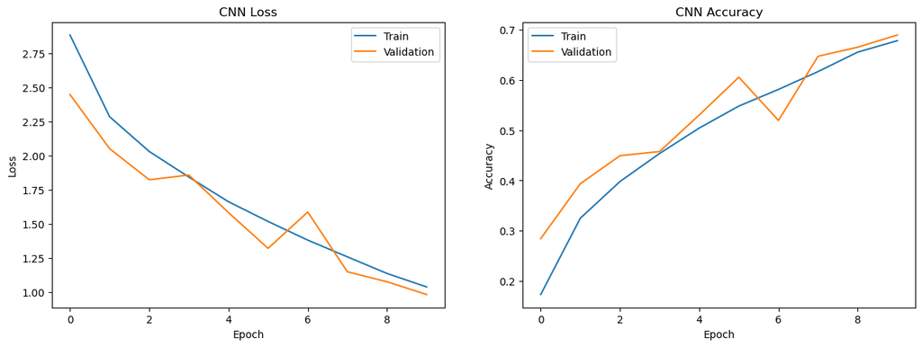

```python
# Your graph
# Plotting CNN
plt.figure(figsize=(15, 5))

plt.subplot(1, 2, 1)
plt.plot(train_losses_cnn, label='Train')
plt.plot(valid_losses_cnn, label='Validation')
plt.title('CNN Loss')
plt.xlabel('Epoch')
plt.ylabel('Loss')
plt.legend()

plt.subplot(1, 2, 2)
plt.plot(train_accuracies_cnn, label='Train')
plt.plot(valid_accuracies_cnn, label='Validation')
plt.title('CNN Accuracy')
plt.xlabel('Epoch')
plt.ylabel('Accuracy')
plt.legend()

plt.show()
```

> Comment on your model and the results you have obtained. This should include the number of parameters for each of your models and briefly explain why one should use CNN over MLP for the image classification problem.

In conclusion, one should use CNN over MLP for image classification problems because:

CNNs are specifically designed to handle spatial information in images, leveraging convolutional layers to extract meaningful features. CNNs typically require fewer parameters compared to fully connected MLPs, making them more computationally efficient. CNNs preserve the spatial structure of images, allowing them to capture local patterns efficiently, which is crucial for image classification tasks.

### 2.2 Generating confusion matrix and ROC curves (6 marks)

- Use your CNN architecture with best accuracy to generate two confusion matrices, one for the training set and another for the validation set. Remember to use the whole validation and training sets, and to include all your relevant code. Display the confusion matrices in a meaningful way which clearly indicates what percentage of the data is represented in each position.
- Display an ROC curve for the two top and two bottom classes with area under the curve

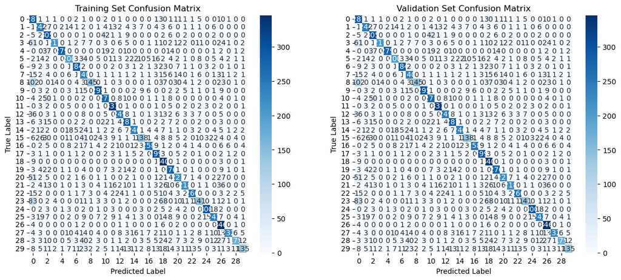

```python
# Your code here!
from sklearn.metrics import confusion_matrix, roc_curve, auc
import seaborn as sns

# Function to make predictions and calculate confusion matrix
def get_predictions(model, data_loader):
    model.eval()
    all_predictions = []
    all_targets = []
    with torch.no_grad():
        for inputs, labels in data_loader:
            inputs, labels = inputs.to(device), labels.to(device)
            outputs = model(inputs)
            _, predicted = torch.max(outputs, 1)
            all_predictions.extend(predicted.cpu().numpy())
            all_targets.extend(labels.cpu().numpy())
    return np.array(all_predictions), np.array(all_targets)

# Getting predictions for training set
train_predictions, train_targets = get_predictions(model_cnn, train_loader)

# Getting predictions for validation set
valid_predictions, valid_targets = get_predictions(model_cnn, valid_loader)

# Calculating confusion matrices
train_conf_matrix = confusion_matrix(train_targets, train_predictions)
valid_conf_matrix = confusion_matrix(valid_targets, valid_predictions)

# Plotting confusion matrices
plt.figure(figsize=(15, 6))

plt.subplot(1, 2, 1)
if train_conf_matrix.size != 0:  # Check if confusion matrix has non-zero size
    sns.heatmap(train_conf_matrix, annot=True, fmt="d", cmap="Blues")
    plt.title("Training Set Confusion Matrix")
    plt.xlabel("Predicted Label")
    plt.ylabel("True Label")
else:
    print("Training confusion matrix is empty")

plt.subplot(1, 2, 2)
if valid_conf_matrix.size != 0:  # Check if confusion matrix has non-zero size
    sns.heatmap(valid_conf_matrix, annot=True, fmt="d", cmap="Blues")
    plt.title("Validation Set Confusion Matrix")
    plt.xlabel("Predicted Label")
    plt.ylabel("True Label")
else:
    print("Validation confusion matrix is empty")

plt.show()
```

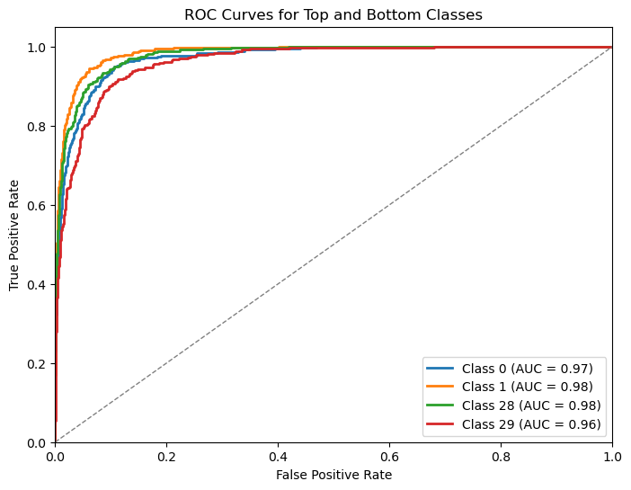

```python
# Function to make predictions and calculate confusion matrix
from sklearn.preprocessing import label_binarize

def get_predictions(model, data_loader):
    model.eval()
    all_predictions = []
    all_targets = []
    all_probabilities = []  # Store predicted probabilities
    with torch.no_grad():
        for inputs, labels in data_loader:
            inputs, labels = inputs.to(device), labels.to(device)
            outputs = model(inputs)
            _, predicted = torch.max(outputs, 1)
            all_predictions.extend(predicted.cpu().numpy())
            all_targets.extend(labels.cpu().numpy())
            all_probabilities.extend(torch.nn.functional.softmax(outputs, dim=1).cpu().numpy())  # Softmax probabilities
    return np.array(all_predictions), np.array(all_targets), np.array(all_probabilities)

# Getting predictions for validation set with probabilities
valid_predictions, valid_targets, valid_probabilities = get_predictions(model_cnn, valid_loader)

# Convert labels to one-hot encoding
valid_targets_onehot = label_binarize(valid_targets, classes=np.arange(num_classes))

# Computing ROC curve and ROC area for each class
fpr = dict()
tpr = dict()
roc_auc = dict()

for i in range(num_classes):
    fpr[i], tpr[i], _ = roc_curve(valid_targets_onehot[:, i], valid_probabilities[:, i])  # Use probabilities here
    roc_auc[i] = auc(fpr[i], tpr[i])

# Plotting ROC curve for top two and bottom two classes
plt.figure(figsize=(8, 6))

def plot_roc_curve(fpr, tpr, roc_auc, class_name):
    plt.plot(fpr, tpr, lw=2, label=f'{class_name} (AUC = {roc_auc:.2f})')
classes_to_plot = [0, 1, num_classes-2, num_classes-1]
for i in classes_to_plot:
    plot_roc_curve(fpr[i], tpr[i], roc_auc[i], class_name=f'Class {i}')

plt.plot([0, 1], [0, 1], color='gray', lw=1, linestyle='--')
plt.xlim([0.0, 1.0])
plt.ylim([0.0, 1.05])
plt.xlabel('False Positive Rate')
plt.ylabel('True Positive Rate')
plt.title('ROC Curves for Top and Bottom Classes')
plt.legend(loc="lower right")
plt.show()
```

### Redesign your CNN model (optional)

> This is optional and does not carry any marks. Often to tackle model underfitting we tend to make more complex network design. Depending on your observation, you can improve your model if you wish.

```python
# Your code here (optional)
```

**Note: All questions below here relates to the CNN model only and not an MLP model! You are advised to use your final CNN model only for each of the questions below.**

### 2.3 Strategies for tackling overfitting (18 marks)

Using your (final) CNN model perform the strategies below to avoid overfitting problems. You can resuse the network weights from previous training, often referred to as `fine tuning`.

- **2.3.1** Data augmentation
- **2.3.2** Dropout
- **2.3.3** Hyperparameter tuning (e.g. changing learning rate)

> Plot loss and accuracy graphs per epoch side by side for each implemented strategy.

#### 2.3.1 Data augmentation (6 marks)

> Implement at least five different data augmentation techniques that should include both photometric and geometric augmentations.

> Provide graphs and comment on what you observe.

```python
# Defining transforms for data augmentation and normalization
# Defining transforms for data augmentation and normalization
augmentation_transform = transforms.Compose([
    transforms.RandomHorizontalFlip(),
    transforms.RandomRotation(10),
    transforms.ColorJitter(brightness=0.2, contrast=0.2, saturation=0.2, hue=0.1),
    transforms.RandomResizedCrop(64, scale=(0.8, 1.0), ratio=(0.75, 1.333)),
    transforms.ToTensor(),  # Convert to tensor first
    transforms.Normalize(mean=[0.485, 0.456, 0.406], std=[0.229, 0.224, 0.225]),
])

# Creating augmented dataset
augmented_dataset = ImageNetDataset(root_dir=root_dir, transform=augmentation_transform)

# Splitting train and validation sets
augmented_dataset.split_train_val()

# Creating DataLoaders for augmented train and validation sets
augmented_train_loader = DataLoader(augmented_dataset, batch_size=64, shuffle=True)
augmented_valid_loader = DataLoader(augmented_dataset, batch_size=64, shuffle=False)

# Training the CNN model with data augmentation
model_cnn.to(device)
augmented_train_losses_cnn, augmented_train_accuracies_cnn, augmented_valid_losses_cnn, augmented_valid_accuracies_cnn = train_model(model_cnn, augmented_train_loader, augmented_valid_loader, criterion, optimizer_cnn,num_epochs=10)
```

```
Training set size after splitting: 10800
Validation set size after splitting: 2700
Training set size after splitting: 10800
Validation set size after splitting: 2700
Epoch [1/10], Train Loss: 3.0393, Train Acc: 0.1305, Valid Loss: 2.7171, Valid Acc: 0.2116
Epoch [2/10], Train Loss: 2.5958, Train Acc: 0.2394, Valid Loss: 2.4170, Valid Acc: 0.2957
Epoch [3/10], Train Loss: 2.4370, Train Acc: 0.2901, Valid Loss: 2.3780, Valid Acc: 0.3081
Epoch [4/10], Train Loss: 2.3010, Train Acc: 0.3275, Valid Loss: 2.1824, Valid Acc: 0.3594
Epoch [5/10], Train Loss: 2.2023, Train Acc: 0.3563, Valid Loss: 2.1832, Valid Acc: 0.3655
Epoch [6/10], Train Loss: 2.1182, Train Acc: 0.3766, Valid Loss: 2.2039, Valid Acc: 0.3535
Epoch [7/10], Train Loss: 2.0675, Train Acc: 0.3928, Valid Loss: 2.0348, Valid Acc: 0.4009
Epoch [8/10], Train Loss: 1.9790, Train Acc: 0.4156, Valid Loss: 1.9313, Valid Acc: 0.4389
Epoch [9/10], Train Loss: 1.9309, Train Acc: 0.4221, Valid Loss: 1.8070, Valid Acc: 0.4671
Epoch [10/10], Train Loss: 1.8786, Train Acc: 0.4427, Valid Loss: 1.8043, Valid Acc: 0.4667
```

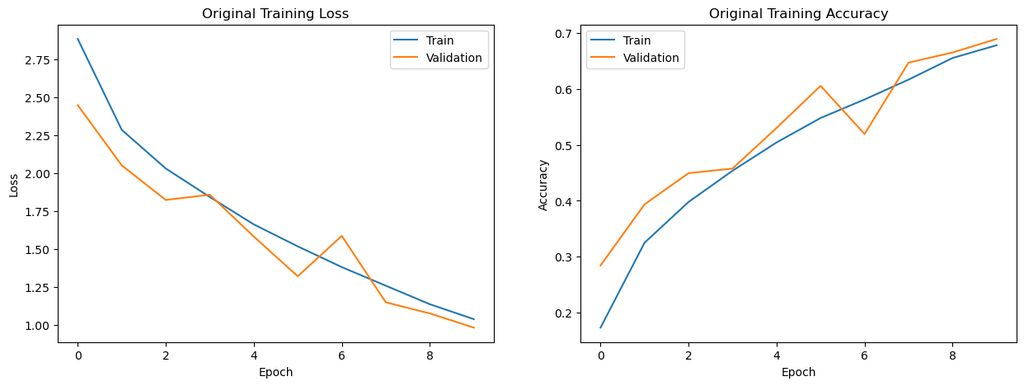

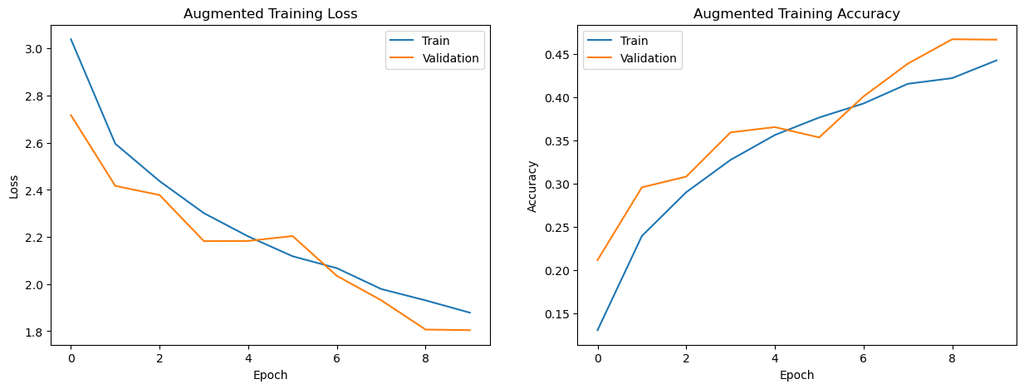

```python
# Plotting original and augmented training graphs side by side
plt.figure(figsize=(15, 5))

# Plotting original training
plt.subplot(1, 2, 1)
plt.plot(train_losses_cnn, label='Train')
plt.plot(valid_losses_cnn, label='Validation')
plt.title('Original Training Loss')
plt.xlabel('Epoch')
plt.ylabel('Loss')
plt.legend()

plt.subplot(1, 2, 2)
plt.plot(train_accuracies_cnn, label='Train')
plt.plot(valid_accuracies_cnn, label='Validation')
plt.title('Original Training Accuracy')
plt.xlabel('Epoch')
plt.ylabel('Accuracy')
plt.legend()

plt.show()

# Plotting augmented training
plt.figure(figsize=(15, 5))

plt.subplot(1, 2, 1)
plt.plot(augmented_train_losses_cnn, label='Train')
plt.plot(augmented_valid_losses_cnn, label='Validation')
plt.title('Augmented Training Loss')
plt.xlabel('Epoch')
plt.ylabel('Loss')
plt.legend()

plt.subplot(1, 2, 2)
plt.plot(augmented_train_accuracies_cnn, label='Train')
plt.plot(augmented_valid_accuracies_cnn, label='Validation')
plt.title('Augmented Training Accuracy')
plt.xlabel('Epoch')
plt.ylabel('Accuracy')
plt.legend()

plt.show()
```

#### 2.3.2 Dropout (6 marks)

> Implement dropout in your model

> Provide graphs and comment on your choice of proportion used.

```python
import torch

# Checking if GPU is available, if not, use CPU
device = torch.device('cuda' if torch.cuda.is_available() else 'cpu')
```

```python
# Your code here!
# Implementing dropout in the model
import torch.nn as nn

class SimpleCNNWithDropout(nn.Module):
    def __init__(self, input_channels, num_classes, dropout_prob=0.2):
        super(SimpleCNNWithDropout, self).__init__()
        self.conv1 = nn.Conv2d(input_channels, 16, kernel_size=3, stride=1, padding=1)
        self.conv2 = nn.Conv2d(16, 32, kernel_size=3, stride=1, padding=1)
        self.pool = nn.MaxPool2d(kernel_size=2, stride=2)
        self.fc1 = nn.Linear(32 * 16 * 16, 128)
        self.dropout = nn.Dropout(dropout_prob)  # Dropout layer
        self.fc2 = nn.Linear(128, num_classes)

    def forward(self, x):
        x = self.pool(nn.functional.relu(self.conv1(x)))
        x = self.pool(nn.functional.relu(self.conv2(x)))
        x = x.view(-1, 32 * 16 * 16)
        x = nn.functional.relu(self.fc1(x))
        x = self.dropout(x)  # Apply dropout
        x = self.fc2(x)
        return x
```

```python
# Defining the CNN model with dropout
model_cnn_with_dropout = SimpleCNNWithDropout(input_channels, num_classes)

# Defining the criterion and optimizer
criterion = nn.CrossEntropyLoss()
learning_rate = 0.001
optimizer_cnn_with_dropout = optim.Adam(model_cnn_with_dropout.parameters(), lr=learning_rate)

# Training the CNN model with dropout
model_cnn.to(device)
train_losses_cnn_dropout, train_accuracies_cnn_dropout, valid_losses_cnn_dropout, valid_accuracies_cnn_dropout = train_model(model_cnn_with_dropout, train_loader, valid_loader, criterion, optimizer_cnn_with_dropout)
```

[output not shown]

[figure not shown]

```python
# Plotting loss and accuracy graphs for both models
plt.figure(figsize=(15, 5))

# Plot loss
plt.subplot(1, 2, 1)
plt.plot(train_losses_cnn, label='Train (without dropout)')
plt.plot(valid_losses_cnn, label='Validation (without dropout)')
plt.plot(train_losses_cnn_dropout, label='Train (with dropout)')
plt.plot(valid_losses_cnn_dropout, label='Validation (with dropout)')
plt.title('CNN Loss')
plt.xlabel('Epoch')
plt.ylabel('Loss')
plt.legend()

# Plotting accuracy
plt.subplot(1, 2, 2)
plt.plot(train_accuracies_cnn, label='Train (without dropout)')
plt.plot(valid_accuracies_cnn, label='Validation (without dropout)')
plt.plot(train_accuracies_cnn_dropout, label='Train (with dropout)')
plt.plot(valid_accuracies_cnn_dropout, label='Validation (with dropout)')
plt.title('CNN Accuracy')
plt.xlabel('Epoch')
plt.ylabel('Accuracy')
plt.legend()

plt.show()
```

#### 2.3.3 Hyperparameter tuning (6 marks)

> Provide graphs each for loss and accuracy at three different learning rates in a single graph.

```python
# Your code here!

import torch.optim as optim

# Define a range of learning rates to try
learning_rates = [0.001, 0.0001, 0.00001]

# Lists to store results for each learning rate
train_losses_lr = []
train_accuracies_lr = []
valid_losses_lr = []
valid_accuracies_lr = []

for lr in learning_rates:
    # Define the optimizer with current learning rate
    optimizer_cnn_lr = optim.Adam(model_cnn.parameters(), lr=lr)

    # Train the CNN model with current learning rate
    model_cnn.to(device)
    train_losses, train_accuracies, valid_losses, valid_accuracies = train_model(model_cnn, train_loader, valid_loader, criterion, optimizer_cnn_lr)

    # Store the results
    train_losses_lr.append(train_losses)
    train_accuracies_lr.append(train_accuracies)
    valid_losses_lr.append(valid_losses)
    valid_accuracies_lr.append(valid_accuracies)
```

[output not shown]

[figure not shown]

[figure not shown]

```python
# Your graph
# Plotting
plt.figure(figsize=(12, 6))

# Plotting training loss
plt.subplot(1, 2, 1)
for i, lr in enumerate(learning_rates):
    plt.plot(train_losses_lr[i], label=f'LR={lr}')
plt.title('Training Loss for Different Learning Rates')
plt.xlabel('Epoch')
plt.ylabel('Loss')
plt.legend()

# Plotting validation loss
plt.subplot(1, 2, 2)
for i, lr in enumerate(learning_rates):
    plt.plot(valid_losses_lr[i], label=f'LR={lr}')
plt.title('Validation Loss for Different Learning Rates')
plt.xlabel('Epoch')
plt.ylabel('Loss')
plt.legend()

plt.show()

# Plotting accuracy
plt.figure(figsize=(12, 6))

# Plotting training accuracy
plt.subplot(1, 2, 1)
for i, lr in enumerate(learning_rates):
    plt.plot(train_accuracies_lr[i], label=f'LR={lr}')
plt.title('Training Accuracy for Different Learning Rates')
plt.xlabel('Epoch')
plt.ylabel('Accuracy')
plt.legend()

# Plotting validation accuracy
plt.subplot(1, 2, 2)
for i, lr in enumerate(learning_rates):
    plt.plot(valid_accuracies_lr[i], label=f'LR={lr}')
plt.title('Validation Accuracy for Different Learning Rates')
plt.xlabel('Epoch')
plt.ylabel('Accuracy')
plt.legend()

plt.show()
```

### 3 Model testing [10 marks]

Online evaluation of your model performance on the test set.

> Prepare the dataloader for the testset.

> Write evaluation code for writing predictions.

> Upload it to Kaggle submission page (6 marks)

#### 3.1 Test class and predictions (4 marks)

> Build a test class, prepare a test dataloader and generate predictions

Create a PyTorch `Dataset` for the unlabeled test data in the test_set folder of the Kaggle competition and generate predictions using your final model. Test data can be downloaded [here](https://www.kaggle.com/competitions/comp5623m-artificial-intelligence/data?select=test_set).

```python
import os
import torch
from torchvision import transforms
from torch.utils.data import Dataset, DataLoader
from PIL import Image
import csv

# Defining the test dataset class
class TestDataset(Dataset):
    def __init__(self, root_dir, transform=None):
        self.root_dir = root_dir
        self.transform = transform
        self.images = os.listdir(root_dir)

    def __len__(self):
        return len(self.images)

    def __getitem__(self, idx):
        img_name = self.images[idx]
        img_path = os.path.join(self.root_dir, img_name)
        image = Image.open(img_path).convert("RGB")
        if self.transform:
            image = self.transform(image)
        return image, img_name

# Defining transforms for the test data (resize and normalize)
test_transform = transforms.Compose([
    transforms.Resize((64, 64)),
    transforms.ToTensor(),
    transforms.Normalize(mean=[0.485, 0.456, 0.406], std=[0.229, 0.224, 0.225])
])

# Specifying the path to the test dataset
test_root_dir = "/Users/bneepunkumar/Downloads/test_set/"  # Update with the path to your test dataset folder

# Creating the test dataset
test_dataset = TestDataset(root_dir=test_root_dir, transform=test_transform)

# Creating a DataLoader for the test dataset
test_loader = DataLoader(test_dataset, batch_size=64, shuffle=False)

# Evaluating the model and generate predictions
def generate_predictions(model, test_loader):
    model.eval()
    predictions = []

    with torch.no_grad():
        for inputs, img_names in test_loader:
            inputs = inputs.to(device)
            outputs = model(inputs)
            _, predicted = outputs.max(1)
            predicted_labels = predicted.tolist()
            predictions.extend(zip(img_names, predicted_labels))

    return predictions

# Using the trained model to generate predictions
# Assuming you have already trained and saved your model as 'model_cnn_augmented'
model_cnn.eval()  # Set the model to evaluation mode
predictions = generate_predictions(model_cnn, test_loader)

# Saving the predictions to a CSV file for submission to Kaggle
output_file = "sc23nkb.csv"  # Replace 'sc15jb' with your student username

with open(output_file, mode='w', newline='') as file:
    writer = csv.writer(file)
    writer.writerow(['Id', 'Category'])
    writer.writerows(predictions)

print("Predictions saved to", output_file)
```

```
Predictions saved to sc23nkb.csv
```

#### 3.2 Prepare your submission and upload to Kaggle (6 marks)

Save all test predictions to a CSV file and submit it to the private class Kaggle competition. **Please save your test CSV file submissions using your student username (the one with letters, e.g., `sc15jb`, not the ID with only numbers)**, for example, `sc15jb.csv`. That will help us to identify your submissions.

The CSV file must contain only two columns: ‘Id’ and ‘Category’ (predicted class ID) as shown below:

```
txt
Id,Category
28d0f5e9_373c.JPEG,2
bbe4895f_40bf.JPEG,18
```

The ‘Id’ column should include the name of the image. It is important to keep the same name as the one on the test set. Do not include any path, just the name of file (with extension). Your csv file must contain 1501 rows, one for each image on test set and 1 row for the headers. [To submit please click here.](https://www.kaggle.com/t/917fe52f6a3c4855880a24b34f26db07)

> You may submit multiple times. We will use your personal top entry for allocating marks for this [6 marks].

### 4 Model Fine-tuning/transfer learning on CIFAR10 dataset [16 marks]

Fine-tuning is a way of applying or utilizing transfer learning. It is a process that takes a model that has already been trained for one given task and then tunes or tweaks the model to make it perform a second similar task. You can perform fine-tuning in following fashion:

- Train an entire model: Start training model from scratch (large dataset, more computation)
- Train some layers, freeze others: Lower layer features are general (problem independent) while higher layer features are specific (problem dependent – freeze)
- Freeze convolution base and train only last FC layers (small dataset and lower computation)

> **Configuring your dataset**
> - Download your dataset using `torchvision.datasets.CIFAR10` [explained here](https://pytorch.org/vision/stable/generated/torchvision.datasets.CIFAR10.html)
> - Split training dataset into training and validation set similar to above. *Note that the number of categories here is only 10*

```python
# Your code here!
import torch
import torchvision
import torchvision.transforms as transforms
import torch.nn as nn
import torch.optim as optim
from torchvision import models


    # Load pre-trained AlexNet
model1 = models.alexnet(pretrained=True)

    # Modifying the fully connected layers according to CIFAR-10
model1.classifier[6] = nn.Linear(4096, 10)

     # Printing trainable parameters
for name, param in model1.named_parameters():
    if param.requires_grad:
        print(name, param.shape)
```

```
features.0.weight torch.Size([64, 3, 11, 11])
features.0.bias torch.Size([64])
features.3.weight torch.Size([192, 64, 5, 5])
features.3.bias torch.Size([192])
features.6.weight torch.Size([384, 192, 3, 3])
features.6.bias torch.Size([384])
features.8.weight torch.Size([256, 384, 3, 3])
features.8.bias torch.Size([256])
features.10.weight torch.Size([256, 256, 3, 3])
features.10.bias torch.Size([256])
classifier.1.weight torch.Size([4096, 9216])
classifier.1.bias torch.Size([4096])
classifier.4.weight torch.Size([4096, 4096])
classifier.4.bias torch.Size([4096])
classifier.6.weight torch.Size([10, 4096])
classifier.6.bias torch.Size([10])
```

> Load pretrained AlexNet from PyTorch - use model copies to apply transfer learning in different configurations

```python
# Your code here!
# Data preparation
# Data preparation
transform = transforms.Compose([
    transforms.Resize((224, 224)),
    transforms.ToTensor(),
    transforms.Normalize((0.5, 0.5, 0.5), (0.5, 0.5, 0.5))
])

trainset = torchvision.datasets.CIFAR10(root='./data', train=True,
                                        download=True, transform=transform)
trainloader = torch.utils.data.DataLoader(trainset, batch_size=8,
                                          shuffle=True, num_workers=2)

testset = torchvision.datasets.CIFAR10(root='./data', train=False,
                                       download=True, transform=transform)
testloader = torch.utils.data.DataLoader(testset, batch_size=8,
                                         shuffle=False, num_workers=2)

device = torch.device("cuda:0" if torch.cuda.is_available() else "cpu")
```

```
Downloading https://www.cs.toronto.edu/~kriz/cifar-10-python.tar.gz to ./data/cifar-10-python.tar.gz
```

```
Extracting ./data/cifar-10-python.tar.gz to ./data
Files already downloaded and verified
```

#### 4.1 Apply transfer learning with pretrained model weights (6 marks)

> Configuration 1: No frozen layers

```python
criterion_alexnet = nn.CrossEntropyLoss()
optimizer_alexnet = optim.Adam(model1.parameters(), lr = 0.001)

num_epochs = 500
alexnet_accuracies_losses = train_model(model1.to(device),trainloader,testloader,criterion_alexnet.to(device), optimizer_alexnet,num_epochs=5)
```

```
Epoch [1/5], Train Loss: 2.3032, Train Acc: 0.1007, Valid Loss: 2.3028, Valid Acc: 0.1000
Epoch [2/5], Train Loss: 2.3031, Train Acc: 0.1016, Valid Loss: 2.3031, Valid Acc: 0.1000
Epoch [3/5], Train Loss: 2.3032, Train Acc: 0.0999, Valid Loss: 2.3026, Valid Acc: 0.1000
Epoch [4/5], Train Loss: 2.3031, Train Acc: 0.0967, Valid Loss: 2.3029, Valid Acc: 0.1000
Epoch [5/5], Train Loss: 2.3031, Train Acc: 0.1001, Valid Loss: 2.3030, Valid Acc: 0.1000
```

#### 4.2 Fine-tuning model with frozen layers (6 marks)

> Configuration 2: Frozen base convolution blocks

```python
model2 = models.alexnet(pretrained = True)
for param in model2.features.parameters():
    param.requires_grad = False
model2.classifier[6] = nn.Linear(4096,10)

for name, param in model2.named_parameters():
    if param.requires_grad:
        print(name, param.shape)
```

```
classifier.1.weight torch.Size([4096, 9216])
classifier.1.bias torch.Size([4096])
classifier.4.weight torch.Size([4096, 4096])
classifier.4.bias torch.Size([4096])
classifier.6.weight torch.Size([10, 4096])
classifier.6.bias torch.Size([10])
```

```python
criterion_alexnet_frozen = nn.CrossEntropyLoss()
optimizer_alexnet_frozen = optim.Adam(model2.parameters(), lr = 0.001)
num_epochs = 100

alexnet_frozen_accuracies_losses = train_model(model2.to(device), trainloader, testloader,criterion_alexnet_frozen.to(device),optimizer_alexnet_frozen,num_epochs=5)
```

```
Epoch [1/5], Train Loss: 1.0203, Train Acc: 0.6734, Valid Loss: 0.7385, Valid Acc: 0.7523
Epoch [2/5], Train Loss: 0.8634, Train Acc: 0.7222, Valid Loss: 0.6521, Valid Acc: 0.7833
Epoch [3/5], Train Loss: 0.7957, Train Acc: 0.7451, Valid Loss: 0.6151, Valid Acc: 0.8023
Epoch [4/5], Train Loss: 0.7645, Train Acc: 0.7571, Valid Loss: 0.6371, Valid Acc: 0.7930
Epoch [5/5], Train Loss: 0.7326, Train Acc: 0.7673, Valid Loss: 0.6083, Valid Acc: 0.8052
```

#### 4.3 Compare above configurations and comment on performances. (4 marks)

```
Accuracy - Configuration 1 (No frozen layers): 0.1
Accuracy - Configuration 2 (Frozen base convolution blocks): 0.8052
```

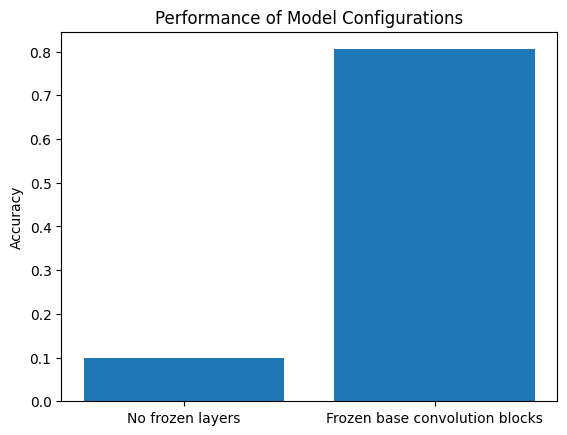

```python
# Your graphs here and please provide comment in markdown in another cell
import matplotlib.pyplot as plt

model_no_frozen = model1
model_frozen = model2
# Function to evaluate model
def evaluate_model(model, dataloader):
    model.eval()
    correct = 0
    total = 0
    with torch.no_grad():
        for data in dataloader:
            inputs, labels = data[0].to(device), data[1].to(device)
            outputs = model(inputs)
            _, predicted = torch.max(outputs.data, 1)
            total += labels.size(0)
            correct += (predicted == labels).sum().item()
    return correct / total

# Evaluating models on validation set
accuracy_no_frozen = evaluate_model(model_no_frozen, testloader)
accuracy_frozen = evaluate_model(model_frozen, testloader)

# Printing accuracy of each configuration
print("Accuracy - Configuration 1 (No frozen layers):", accuracy_no_frozen)
print("Accuracy - Configuration 2 (Frozen base convolution blocks):", accuracy_frozen)

# Plotting bar chart
configurations = ['No frozen layers', 'Frozen base convolution blocks']
accuracies = [accuracy_no_frozen, accuracy_frozen]

plt.bar(configurations, accuracies)
plt.ylabel('Accuracy')
plt.title('Performance of Model Configurations')
plt.show()
```

### Part II: Image Captioning using RNN [30 marks]

### Motivation

Through this part of assessment you will:

> 1. Understand the principles of text pre-processing and vocabulary building (provided).
> 2. Gain experience working with an image to text model.
> 3. Use and compare text similarity metrics for evaluating an image to text model, and understand evaluation challenges.

#### Dataset

This assessment will use a subset of the [COCO "Common Objects in Context" dataset](https://cocodataset.org/) for image caption generation. COCO contains 330K images, of 80 object categories, and at least five textual reference captions per image. Our subset consists of nearly 5070 of these images, each of which has five or more different descriptions of the salient entities and activities, and we will refer to it as COCO_5070.

To download the data:

> 1. **Images and annotations**: download the zipped file provided in the link here as [`COMP5625M_data_assessment_2.zip`](https://leeds365-my.sharepoint.com/:u:/g/personal/scssali_leeds_ac_uk/EWWzE-_AIrlOkvOKxH4rjIgBF_eUx8KDJMPKM2eHwCE0dg?e=DdX62H).

`Info only:` To understand more about the COCO dataset you can look at the [download page](https://cocodataset.org/#download). We have already provided you with the "2017 Train/Val annotations (241MB)" but our image subset consists of fewer images compared to orginial COCO dataset. So, no need to download anything from here!

> 1. **Image meta data**: as our set is a subset of full COCO dataset, we have created a CSV file containing relevant meta data for our particular subset of images. You can download it also from Drive, "coco_subset_meta.csv" at the same link as 1.

#### Submission

You can either submit the same file or make a two separate .ipython notebook files zipped in the submission (please name as `yourstudentusername_partI.ipynb` and `yourstudentusername_partII.ipynb`).

**Final note:**

> **Please include in this notebook everything that you would like to be marked, including figures. Under each section, put the relevant code containing your solution. You may re-use functions you defined previously, but any new code must be in the relevant section.** Feel free to add as many code cells as you need under each section.

The basic principle of our image-to-text model is as pictured in the diagram below, where an Encoder network encodes the input image as a feature vector by providing the outputs of the last fully-connected layer of a pre-trained CNN (we use [ResNet50](https://arxiv.org/abs/1512.03385)). This pretrained network has been trained on the complete ImageNet dataset and is thus able to recognise common objects.

You can alternatively use the COCO trained pretrained weights from [PyTorch](https://pytorch.org/vision/stable/models.html). One way to do this is use the "FasterRCNN_ResNet50_FPN_V2_Weights.COCO_V1" but use e.g., "resnet_model = model.backbone.body". Alternatively, you can use the checkpoint from your previous coursework where you fine-tuned to COCO dataset.

These features are then fed into a Decoder network along with the reference captions. As the image feature dimensions are large and sparse, the Decoder network includes a linear layer which downsizes them, followed by *a batch normalisation layer to speed up training*. Those resulting features, as well as the reference text captions, are then passed into a recurrent network (we will use an **RNNs** in this assessment).

The reference captions used to compute loss are represented as numerical vectors via an **embedding layer** whose weights are learned during training.

[figure not shown]

### Instructions for creating vocabulary

A helper function file `helperDL.py` is provided that includes all the functions that will do the following for you. You can easily import these functions in the exercise, most are already done for you!

> 1. Extracting image features (a trained checkpoint is provided `resnet50_caption.pt` for you to download and use it for training your RNN)
> 2. Text preparation of training and validation data is provided

```python
import torch
import torch.nn as nn
from torchvision import transforms
import torchvision.models as models
from torch.utils.data import Dataset
from torch.nn.utils.rnn import pack_padded_sequence, pad_packed_sequence
import matplotlib.pyplot as plt
from collections import Counter
import os
import numpy as np
```

```python
device = torch.device('cuda' if torch.cuda.is_available() else 'cpu')
print('Using device:', device)
```

**Please refer to the submission section at the top of this notebook to prepare your submission.**

```python
# Load the feature map provided to you
features_map = torch.load('/kaggle/input/resent/resnet50_caption.pt', map_location=device)
```

#### 5 Train DecoderRNN [20 marks]

> 5.1 Design a RNN-based decoder (10 marks)

> 5.2 Train your model with precomputed features (10 Marks)

##### 5.1 Design a RNN-based decoder (10 marks)

Read through the `DecoderRNN` model below. First, complete the decoder by adding an `rnn` layer to the decoder where indicated, using [the PyTorch API as reference](https://pytorch.org/docs/stable/nn.html#rnn).

Keep all the default parameters except for `batch_first`, which you may set to True.

In particular, understand the meaning of `pack_padded_sequence()` as used in `forward()`. Refer to the [PyTorch `pack_padded_sequence()` documentation](https://pytorch.org/docs/stable/generated/torch.nn.utils.rnn.pack_padded_sequence.html).

```python
import json
import pandas as pd

with open('/kaggle/input/captions/captions_train2017.json', 'r') as json_file:
    data = json.load(json_file)

df = pd.DataFrame.from_dict(data["annotations"])
df.head()
```

|  | image_id | id | caption |
| --- | --- | --- | --- |
| 0 | 203564 | 37 | A bicycle replica with a clock as the front wh... |
| 1 | 322141 | 49 | A room with blue walls and a white sink and door. |
| 2 | 16977 | 89 | A car that seems to be parked illegally behind... |
| 3 | 106140 | 98 | A large passenger airplane flying through the ... |
| 4 | 106140 | 101 | There is a GOL plane taking off in a partly cl... |

```python
coco_subset = pd.read_csv("/kaggle/input/coco-meta/coco_subset_meta.csv")
new_data = pd.DataFrame( data['annotations'])
new_coco = coco_subset.rename(columns={'id':'image_id'})
new_coco.drop_duplicates('file_name',keep='first',inplace=True)

new_subset = new_data.sort_values(['image_id'], ascending=True)
# Get all the reference captions
new_file = pd.merge(new_coco,new_subset,how = 'inner', on = 'image_id')
new_file = new_file[['image_id','id','caption','file_name']]
new_file = new_file.sort_values(['image_id'], ascending = True)
new_file.head(10)
```

|  | image_id | id | caption | file_name |
| --- | --- | --- | --- | --- |
| 16759 | 9 | 663627 | there are containers filled with different kin... | 000000000009.jpg |
| 16758 | 9 | 666765 | Colorful dishes holding meat, vegetables, frui... | 000000000009.jpg |
| 16757 | 9 | 667602 | A bunch of trays that have different food. | 000000000009.jpg |
| 16756 | 9 | 661611 | Closeup of bins of food that include broccoli ... | 000000000009.jpg |
| 16755 | 9 | 661977 | A meal is presented in brightly colored plasti... | 000000000009.jpg |
| 9635 | 25 | 133058 | Two giraffes standing in a tree filled area. | 000000000025.jpg |
| 9637 | 25 | 133676 | A giraffe standing next to a forest filled wit... | 000000000025.jpg |
| 9636 | 25 | 122312 | A giraffe eating food from the top of the tree. | 000000000025.jpg |
| 9633 | 25 | 127238 | A giraffe mother with its baby in the forest. | 000000000025.jpg |
| 9634 | 25 | 127076 | A giraffe standing up nearby a tree | 000000000025.jpg |

```python
import urllib.request

# Provide the correct URL to the raw Python file on GitHub
url = 'https://raw.githubusercontent.com/neepunkumar/helperfunction/main/helperDL.py'

# Download the raw Python file
urllib.request.urlretrieve(url, 'helperDL.py')

# Now import the module from the downloaded file
from helperDL import gen_clean_captions_df
```

```python
# getting the clearn clean - e.g., converting all uppercases to lowercases
new_file["clean_caption"] = ""
from helperDL import gen_clean_captions_df
new_file = gen_clean_captions_df(new_file)
new_file.head(10)
```

|  | image_id | id | caption | file_name | clean_caption |
| --- | --- | --- | --- | --- | --- |
| 16759 | 9 | 663627 | there are containers filled with different kin... | 000000000009.jpg | there are containers filled with different kin... |
| 16758 | 9 | 666765 | Colorful dishes holding meat, vegetables, frui... | 000000000009.jpg | colorful dishes holding meat vegetables fruit ... |
| 16757 | 9 | 667602 | A bunch of trays that have different food. | 000000000009.jpg | a bunch of trays that have different food |
| 16756 | 9 | 661611 | Closeup of bins of food that include broccoli ... | 000000000009.jpg | closeup of bins of food that include broccoli ... |
| 16755 | 9 | 661977 | A meal is presented in brightly colored plasti... | 000000000009.jpg | a meal is presented in brightly colored plasti... |
| 9635 | 25 | 133058 | Two giraffes standing in a tree filled area. | 000000000025.jpg | two giraffes standing in a tree filled area |
| 9637 | 25 | 133676 | A giraffe standing next to a forest filled wit... | 000000000025.jpg | a giraffe standing next to a forest filled wit... |
| 9636 | 25 | 122312 | A giraffe eating food from the top of the tree. | 000000000025.jpg | a giraffe eating food from the top of the tree |
| 9633 | 25 | 127238 | A giraffe mother with its baby in the forest. | 000000000025.jpg | a giraffe mother with its baby in the forest |
| 9634 | 25 | 127076 | A giraffe standing up nearby a tree | 000000000025.jpg | a giraffe standing up nearby a tree |

```python
##### Spilt your training, validation and test dataset with indexes to each set
from helperDL import split_ids
train_id, valid_id, test_id = split_ids(new_file['image_id'].unique())
print("training:{}, validation:{}, test:{}".format(len(train_id), len(valid_id), len(test_id)))
```

```
training:3547, validation:506, test:1015
```

```python
train_set = new_file.loc[new_file['image_id'].isin(train_id)]
valid_set = new_file.loc[new_file['image_id'].isin(valid_id)]
test_set = new_file.loc[new_file['image_id'].isin(test_id)]
```

```python
class Vocabulary(object):
    """ Simple vocabulary wrapper which maps every unique word to an integer ID. """
    def __init__(self):
        # intially, set both the IDs and words to dictionaries with special tokens
        self.word2idx = {'<pad>': 0, '<unk>': 1, '<end>': 2}
        self.idx2word = {0: '<pad>', 1: '<unk>', 2: '<end>'}
        self.idx = 3

    def add_word(self, word):
        # if the word does not already exist in the dictionary, add it
        if not word in self.word2idx:
            self.word2idx[word] = self.idx
            self.idx2word[self.idx] = word
            # increment the ID for the next word
            self.idx += 1

    def __call__(self, word):
        # if we try to access a word not in the dictionary, return the id for <unk>
        if not word in self.word2idx:
            return self.word2idx['<unk>']
        return self.word2idx[word]

    def __len__(self):
        return len(self.word2idx)
```

```python
### build vocabulariy for each set - train, val and test
# you will be using to create dataloaders
from helperDL import build_vocab

# create a vocab instance
vocab = Vocabulary()
vocab_train = build_vocab(train_id, new_file, vocab)
vocab_valid = build_vocab(valid_id, new_file, vocab)
vocab_test = build_vocab(test_id, new_file, vocab)

vocab = vocab_train # using only training samples as vocabulary as instructed above
print("Total vocabulary size: {}".format(len(vocab_train)))
```

```
Total vocabulary size: 2353
```

```python
# They can also join the train and valid captions but they will need to run vocabulary after concatenation
import numpy as np
vocab = build_vocab(np.concatenate((train_id, valid_id), axis=0), new_file, vocab) #---> overrighting
len(vocab)
```

```
2523
```

Instantiate a `DataLoader` for your image feature and caption dataset. `helperDL.py` file includes all the required functions

We need to overwrite the default PyTorch collate_fn() because our ground truth captions are sequential data of varying lengths. The default collate_fn() does not support merging the captions with padding.

You can read more about it here: https://pytorch.org/docs/stable/data.html#dataloader-collate-fn.

```python
from helperDL import EncoderCNN
model = EncoderCNN()
print(model)
```

[output not shown]

[output cut: 122 more lines]

```
        (relu): ReLU(inplace=True)
      )
      (2): Bottleneck(
        (conv1): Conv2d(2048, 512, kernel_size=(1, 1), stride=(1, 1), bias=False)
        (bn1): BatchNorm2d(512, eps=1e-05, momentum=0.1, affine=True, track_running_stats=True)
        (conv2): Conv2d(512, 512, kernel_size=(3, 3), stride=(1, 1), padding=(1, 1), bias=False)
        (bn2): BatchNorm2d(512, eps=1e-05, momentum=0.1, affine=True, track_running_stats=True)
        (conv3): Conv2d(512, 2048, kernel_size=(1, 1), stride=(1, 1), bias=False)
        (bn3): BatchNorm2d(2048, eps=1e-05, momentum=0.1, affine=True, track_running_stats=True)
        (relu): ReLU(inplace=True)
      )
    )
    (8): AdaptiveAvgPool2d(output_size=(1, 1))
  )
)
```

```python
# ''' Load the saved image feature maps and trained model ("provided to you") '''

# # ---> your entry here (make sure that the path is correct)
# features = torch.load("coco_features.pt")

# # also load the model ckpt and udate the model state dict of the base model
# # ---> your entry here (make sure that the path is correct)
# checkpoint = torch.load("ckpt file here")
# model.load_state_dict(checkpoint['model_state_dict'])
```

```python
##### Preparing the train, val and test dataloaders
from helperDL import COCO_Features
from helperDL import caption_collate_fn


# Create a dataloader for train
dataset_train = COCO_Features(
    df=train_set,
    vocab=vocab,
    features=features_map,
)

train_loader = torch.utils.data.DataLoader(
    dataset_train,
    batch_size=32,
    shuffle=True,
    num_workers=0, # may need to set to 0
    collate_fn=caption_collate_fn, # explicitly overwrite the collate_fn
)

# Create a dataloader for valid
dataset_valid = COCO_Features(
    df=valid_set,
    vocab=vocab,
    features=features_map,
)

valid_loader = torch.utils.data.DataLoader(
    dataset_valid,
    batch_size=32,
    shuffle=True,
    num_workers=0, # may need to set to 0
    collate_fn=caption_collate_fn, # explicitly overwrite the collate_fn
)
```

```python
# say this is as below
# --> Please change these numbers as required.
# --> Please comment on changes that you do.
EMBED_SIZE = 256
HIDDEN_SIZE = 512
NUM_LAYERS = 1
LR = 0.001
NUM_EPOCHS = 5
LOG_STEP = 10
MAX_SEQ_LEN = 37
```

#### 5.1 Design a RNN-based decoder (10 marks)

Read through the `DecoderRNN` model below. First, complete the decoder by adding an `rnn` layer to the decoder where indicated, using [the PyTorch API as reference](https://pytorch.org/docs/stable/nn.html#rnn).

Keep all the default parameters except for `batch_first`, which you may set to True.

In particular, understand the meaning of `pack_padded_sequence()` as used in `forward()`. Refer to the [PyTorch `pack_padded_sequence()` documentation](https://pytorch.org/docs/stable/generated/torch.nn.utils.rnn.pack_padded_sequence.html).

```python
class DecoderRNN(nn.Module):
    def __init__(self, vocab_size, embed_size=256, hidden_size=512, num_layers=1, max_seq_length=47):
        """Set the hyper-parameters and build the layers."""
        super(DecoderRNN, self).__init__()
        # we want a specific output size, which is the size of our embedding, so
        # we feed our extracted features from the last fc layer (dimensions 1 x 2048)
        # into a Linear layer to resize
        # your code
        self.resize = nn.Linear(2048, embed_size)

        # batch normalisation helps to speed up training
        # your code
        self.bn = nn.BatchNorm1d(embed_size)


        # your code for embedding layer
        self.embed = nn.Embedding(vocab_size, embed_size)


        # your code for RNN

        self.rnn = nn.RNN(embed_size, hidden_size, num_layers, batch_first=True)
        self.linear = nn.Linear(hidden_size, vocab_size)
        self.max_seq_length = max_seq_length


    def forward(self, features, captions, lengths):
        """Decode image feature vectors and generates captions."""
        embeddings = self.embed(captions)
        im_features = self.resize(features)
        im_features = self.bn(im_features)

        # compute your feature embeddings
        embeddings = torch.cat((im_features.unsqueeze(1), embeddings), 1)
        # your code

        # Pack the padded sequence
        packed = nn.utils.rnn.pack_padded_sequence(embeddings, lengths, batch_first=True)
        # pack_padded_sequence returns a PackedSequence object, which contains two items:
        # the packed data (data cut off at its true length and flattened into one list), and
        # the batch_sizes, or the number of elements at each sequence step in the batch.
        # For instance, given data [a, b, c] and [x] the PackedSequence would contain data
        # [a, x, b, c] with batch_sizes=[2,1,1].

        # your code [hint: use pack_padded_sequence]
        # Pass through RNN
        hiddens, _ = self.rnn(packed)

        # Unpack the packed sequence
        outputs = self.linear(hiddens[0]) #hint: use a hidden layers in parenthesis
        return outputs


    def sample(self, features, states=None):
        """Generate captions for given image features using greedy search."""
        sampled_ids = []

        inputs = self.bn(self.resize(features)).unsqueeze(1)
        for i in range(self.max_seq_length):
            hiddens, states = self.rnn(inputs, states)  # hiddens: (batch_size, 1, hidden_size)
            outputs = self.linear(hiddens.squeeze(1))   # outputs:  (batch_size, vocab_size)
            _, predicted = outputs.max(1)               # predicted: (batch_size)
            sampled_ids.append(predicted)
            inputs = self.embed(predicted)              # inputs: (batch_size, embed_size)
            inputs = inputs.unsqueeze(1)                # inputs: (batch_size, 1, embed_size)
        sampled_ids = torch.stack(sampled_ids, 1)       # sampled_ids: (batch_size, max_seq_length)
        return sampled_ids
```

```python
# instantiate decoder
decoder = DecoderRNN(len(vocab), embed_size=EMBED_SIZE, hidden_size=HIDDEN_SIZE, num_layers=NUM_LAYERS).to(device)
```

##### 5.2 Train your model with precomputed features (10 marks)

Train the decoder by passing the features, reference captions, and targets to the decoder, then computing loss based on the outputs and the targets. Note that when passing the targets and model outputs to the loss function, the targets will also need to be formatted using `pack_padded_sequence()`.

We recommend a batch size of around 64 (though feel free to adjust as necessary for your hardware).

**We strongly recommend saving a checkpoint of your trained model after training so you don't need to re-train multiple times.**

Display a graph of training and validation loss over epochs to justify your stopping point.

```python
import torch.optim as optim
# loss and optimizer here
# your code here --->

criterion = nn.CrossEntropyLoss()
optimizer = optim.Adam(decoder.parameters(), lr=0.001)


# train the models
total_step = len(train_loader)
total_step_v = len(valid_loader)
stats = np.zeros((NUM_EPOCHS,2))
print(stats.shape)
total_loss = 0
for epoch in range(NUM_EPOCHS):
    for i, (features_, captions_, lengths_) in enumerate(train_loader):
        # your code here --->

        features_ = features_.to(device)
        captions_ = captions_.to(device)
        targets = pack_padded_sequence(captions_, lengths_, batch_first=True)[0]

        # Forward, backward and optimize
        decoder.train()
        optimizer.zero_grad()
        outputs = decoder(features_, captions_, lengths_)
        loss = criterion(outputs, targets)
        loss.backward()
        optimizer.step()





        total_loss += loss.item()

        # print stats
        if i % LOG_STEP == 0:
            print(f"Epoch [{epoch+1}/{NUM_EPOCHS}], Step [{i}/{total_step}], Loss: {loss.item():.4f}")

    stats[epoch,0] = round(total_loss/total_step,3)
    total_loss = 0

    #validation
    decoder.eval()
    with torch.no_grad():
        for i, (features_, captions_, lengths_) in enumerate(valid_loader):
            # your code here --->
            features_ = features_.to(device)
            captions_ = captions_.to(device)
            targets = pack_padded_sequence(captions_, lengths_, batch_first=True)[0]

            outputs = decoder(features_, captions_, lengths_)
            loss = criterion(outputs, targets)

            total_loss += loss.item()





    stats[epoch,1] = round(total_loss/total_step_v,3)
    total_loss = 0
    # print stats
    print("="*30)
    print(f"Epoch [{epoch+1}/{NUM_EPOCHS}], Train_Loss: {stats[epoch,0]}, Valid_Loss: {stats[epoch,1]}")
    print("="*30)
    decoder.train()
    import torch.optim as optim
```

```
(5, 2)
Epoch [1/5], Step [0/555], Loss: 7.8722
Epoch [1/5], Step [10/555], Loss: 5.6592
Epoch [1/5], Step [20/555], Loss: 5.3510
Epoch [1/5], Step [30/555], Loss: 5.3238
Epoch [1/5], Step [40/555], Loss: 4.8522
Epoch [1/5], Step [50/555], Loss: 4.7723
Epoch [1/5], Step [60/555], Loss: 4.3495
Epoch [1/5], Step [70/555], Loss: 4.6235
Epoch [1/5], Step [80/555], Loss: 4.3409
Epoch [1/5], Step [90/555], Loss: 4.0379
Epoch [1/5], Step [100/555], Loss: 4.4227
Epoch [1/5], Step [110/555], Loss: 4.0962
Epoch [1/5], Step [120/555], Loss: 3.7447
Epoch [1/5], Step [130/555], Loss: 3.9907
Epoch [1/5], Step [140/555], Loss: 3.9505
Epoch [1/5], Step [150/555], Loss: 4.4014
Epoch [1/5], Step [160/555], Loss: 3.7427
Epoch [1/5], Step [170/555], Loss: 3.8673
Epoch [1/5], Step [180/555], Loss: 3.8389
Epoch [1/5], Step [190/555], Loss: 3.8795
Epoch [1/5], Step [200/555], Loss: 3.5589
Epoch [1/5], Step [210/555], Loss: 3.6319
Epoch [1/5], Step [220/555], Loss: 3.8219
Epoch [1/5], Step [230/555], Loss: 3.4199
Epoch [1/5], Step [240/555], Loss: 3.7472
Epoch [1/5], Step [250/555], Loss: 3.8311
Epoch [1/5], Step [260/555], Loss: 3.4233
Epoch [1/5], Step [270/555], Loss: 3.3219
Epoch [1/5], Step [280/555], Loss: 3.6264
Epoch [1/5], Step [290/555], Loss: 3.3337
Epoch [1/5], Step [300/555], Loss: 3.7011
Epoch [1/5], Step [310/555], Loss: 3.7700
Epoch [1/5], Step [320/555], Loss: 3.2400
Epoch [1/5], Step [330/555], Loss: 3.3280
Epoch [1/5], Step [340/555], Loss: 3.3996
Epoch [1/5], Step [350/555], Loss: 3.1833
Epoch [1/5], Step [360/555], Loss: 3.2613
Epoch [1/5], Step [370/555], Loss: 3.7220
Epoch [1/5], Step [380/555], Loss: 3.3682
```

[output cut: 241 more lines]

```
Epoch [5/5], Step [440/555], Loss: 2.5199
Epoch [5/5], Step [450/555], Loss: 2.3967
Epoch [5/5], Step [460/555], Loss: 2.2972
Epoch [5/5], Step [470/555], Loss: 2.1230
Epoch [5/5], Step [480/555], Loss: 2.3073
Epoch [5/5], Step [490/555], Loss: 2.4422
Epoch [5/5], Step [500/555], Loss: 2.3856
Epoch [5/5], Step [510/555], Loss: 2.2961
Epoch [5/5], Step [520/555], Loss: 2.3254
Epoch [5/5], Step [530/555], Loss: 2.6058
Epoch [5/5], Step [540/555], Loss: 2.2235
Epoch [5/5], Step [550/555], Loss: 2.5838
==============================
Epoch [5/5], Train_Loss: 2.275, Valid_Loss: 2.95
==============================
```

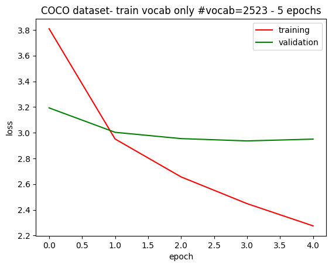

```python
fig = plt.figure()

plt.plot(stats[:,0], 'r', label = 'training', )
plt.plot(stats[:,1], 'g', label = 'validation' )
plt.legend()
plt.xlabel('epoch')
plt.ylabel('loss')
plt.title(f"COCO dataset- train vocab only #vocab={len(vocab)} - 5 epochs")
fig.savefig("coco_train_vocab_only.png")
plt.show()
```

```python
# save model after training
decoder_ckpt = torch.save(decoder, "coco_subset_assessment_decoder.ckpt")
```

### 6 Test prediction and evaluation [10 marks]

#### 6.1 Generate predictions on test data (4 marks)

Display 4 sample test images containing different objects, along with your model’s generated captions and all the reference captions for each.

> Remember that everything **displayed** in the submitted notebook and .html file will be marked, so be sure to run all relevant cells.

```python
import os
import torch
from torch.utils.data import Dataset
from torchvision import transforms
from PIL import Image

class COCOImagesDataset(Dataset):
    def __init__(self, df, images_path, transform=None,device='cpu'):
        self.df = df
        self.images_path = images_path
        self.transform = transform
        self.device = device

    def __len__(self):
        return len(self.df)

    def __getitem__(self, idx):
        file_name = self.df.iloc[idx]['file_name']
        image_path = os.path.join(self.images_path, file_name)

        if os.path.exists(image_path):
            image = Image.open(image_path).convert('RGB')

            if self.transform:
                image = self.transform(image)
            image = image.to(self.device)
            return image, file_name
        else:
            raise FileNotFoundError(f"Image file not found: {image_path}")
```

```python
data_transform = transforms.Compose([
    transforms.Resize(224),
    transforms.CenterCrop(224),
    transforms.ToTensor(),
    transforms.Normalize((0.485, 0.456, 0.406),   # using ImageNet norms
                         (0.229, 0.224, 0.225))])
   # transforms.Normalize((0.5, 0.5, 0.5), (0.5, 0.5, 0.5))])

dataset_test = COCOImagesDataset(
    df=test_set,
    images_path = "/kaggle/input/coco-images/images",
    transform = data_transform,
    device='cuda:0'
)
test_loader = torch.utils.data.DataLoader(
    dataset_test,
    batch_size=32,
    shuffle=False,
    num_workers=0)
```

```python
model.eval().to(device)
decoder.eval().to(device) # generate caption, eval mode to not influence batchnormncoder.eval()
```

```
DecoderRNN(
  (resize): Linear(in_features=2048, out_features=256, bias=True)
  (bn): BatchNorm1d(256, eps=1e-05, momentum=0.1, affine=True, track_running_stats=True)
  (embed): Embedding(2523, 256)
  (rnn): RNN(256, 512, batch_first=True)
  (linear): Linear(in_features=512, out_features=2523, bias=True)
)
```

```python
# getting functions from helperDL.py
from helperDL import timshow
from helperDL import decode_caption
```

```
Generated caption: a woman in a blue shirt is holding a hotdog
Reference caption: a man and woman cut into a big cake
===================================
```

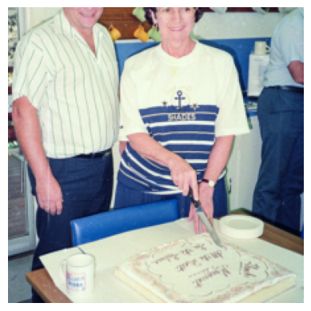

```
Generated caption: two elephants are standing in a grassy area
Reference caption: a herd of elephants one running with a baby
===================================
```

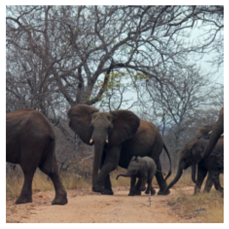

```
Generated caption: a bathroom with a toilet and a bathtub
Reference caption: the toilet in the small stall has the lit up
===================================
```

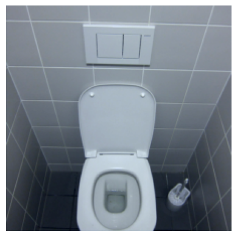

```
Generated caption: a baseball game in progress with a baseball bat
Reference caption: a group of baseball players standing on top of a field
===================================
```

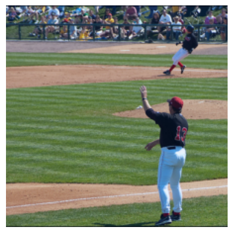

```python
IMAGES_TO_SHOW = 4

with torch.no_grad():
    for i, (image, filename) in enumerate(test_loader):

        # Generating captions
        image = image.to(device)
        generated_captions = decoder.sample(model(image))
        generated_words = []
        for idx in generated_captions[0]:
            word = vocab.idx2word[idx.item()]
            if word == '<end>':
                break
            generated_words.append(word)

        # Printing generated caption
        print(f"Generated caption: {' '.join(generated_words)}")

        # Accessing reference caption
        # Extracting the filename from the tuple
        filename = filename[0]
        if filename in test_set['file_name'].values:
            reference_caption = test_set.loc[test_set['file_name'] == filename, 'clean_caption'].values[0]
            print("Reference caption:", reference_caption)
        else:
            print("Reference caption not found for", filename)
        print("===================================\n")

        # Showing image
        timshow(image[0].cpu())

        if i + 1 == IMAGES_TO_SHOW:
            break
```

#### 6.2 Caption evaluation using cosine similarity (6 marks)

The cosine similarity measures the cosine of the angle between two vectors in n-dimensional space. The smaller the angle, the greater the similarity.

To use the cosine similarity to measure the similarity between the generated caption and the reference captions:

- Find the embedding vector of each word in the caption
- Compute the average vector for each caption
- Compute the cosine similarity score between the average vector of the generated caption and average vector of each reference caption
- Compute the average of these scores

Calculate the cosine similarity using the model's predictions over the whole test set.

Display a histogram of the distribution of scores over the test set.

```
Average Cosine Similarity Score: 0.014413109
```

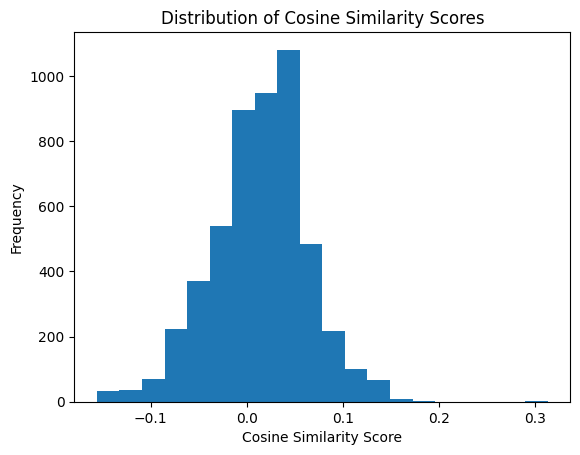

```python
# your code here
from sklearn.metrics.pairwise import cosine_similarity
import numpy as np
from torch.nn.utils.rnn import pad_sequence

# Function to compute cosine similarity between two vectors
def compute_cosine_similarity(vector1, vector2):
    # Reshape the input vectors to 2D arrays
    vector1 = vector1.reshape(1, -1)
    vector2 = vector2.reshape(1, -1)

    # Computing cosine similarity
    similarity_score = cosine_similarity(vector1, vector2)
    return similarity_score[0][0]

# Initialize lists to store cosine similarity scores for each image
cosine_similarity_scores = []

# Iterate through the test dataset
with torch.no_grad():
    for i, (image, filename) in enumerate(test_loader):
        # Generating captions
        generated_captions = decoder.sample(model(image))

        # Accessing reference caption
        filename = filename[0]  # Extract the filename from the tuple
        if filename in test_set['file_name'].values:
            reference_caption = test_set.loc[test_set['file_name'] == filename, 'clean_caption'].values[0]

            # Tokenizing reference caption
            reference_tokens = reference_caption.split()
            # Filtering out tokens not present in the vocabulary
            reference_tokens = [word for word in reference_tokens if word in vocab.word2idx]
            # Converting tokens to indices
            reference_indices = [vocab.word2idx[word] for word in reference_tokens]
            # Converting indices to tensor
            reference_indices_tensor = torch.tensor(reference_indices).unsqueeze(0).to(device)
            # Extracting word embeddings for reference caption
            reference_word_embeddings = decoder.embed(reference_indices_tensor)
            # Computing average vector for reference caption
            reference_caption_avg = torch.mean(reference_word_embeddings, dim=1).squeeze(0)

            # Iterating through generated captions
            for idx_sequence in generated_captions:
                # Extracting word embeddings
                word_embeddings = decoder.embed(idx_sequence)
                # Pad sequences to ensure they have the same length
                padded_reference_embeddings = pad_sequence([reference_word_embeddings.squeeze(0)], batch_first=True)
                padded_generated_embeddings = pad_sequence([word_embeddings.squeeze(0)], batch_first=True)
                # Computing average vector for generated caption
                reference_caption_avg = torch.mean(padded_reference_embeddings, dim=1).squeeze(0)
                generated_caption_avg = torch.mean(padded_generated_embeddings, dim=1).squeeze(0)

                # Computing cosine similarity scores between generated caption and reference caption
                similarity_score = compute_cosine_similarity(generated_caption_avg.cpu().numpy(), reference_caption_avg.cpu().numpy())
                cosine_similarity_scores.append(similarity_score)
        else:
            print("Reference caption not found for", filename)

# Converting cosine similarity scores to numpy array
cosine_similarity_scores = np.array(cosine_similarity_scores)

# Computing the average cosine similarity score
average_cosine_similarity = np.mean(cosine_similarity_scores)

# Displaying the average cosine similarity score
print("Average Cosine Similarity Score:", average_cosine_similarity)

# Plotting histogram of cosine similarity scores
import matplotlib.pyplot as plt
plt.hist(cosine_similarity_scores, bins=20)
plt.xlabel('Cosine Similarity Score')
plt.ylabel('Frequency')
plt.title('Distribution of Cosine Similarity Scores')
plt.show()
```

##### Thank you for completing the assessment - if you have any question, please ask on teams channel or attend lab sessions on Tuesdays and Wednesdays.